# RNA-seq Analysis in R

Annotation and Visualisation of RNA-seq results - Solutions

Stephane Ballereau, Dominique-Laurent Couturier, Mark Dunning, Abbi Edwards, Ashley Sawle

Last modified: 20 Jul 2020

## Exercise 1 - Retrieve the full annotation

> So far we have retrieved the annotation for just 1000 genes, but we need annotations for the entire results table.

> A reminder of the code we have used so far:

```r
# lets set it up
ourCols <- c("GENEID", "SYMBOL", "ENTREZID")
ourKeys <- rownames(resLvV)[1:1000]

# run the query
annot <- AnnotationDbi::select(EnsDb.Mmusculus.v79,
                keys=ourKeys,
                columns=ourCols,
                keytype="GENEID")
```

> 1. Run the same query using all of the genes in our results table (`resLvV`), and this time include the biotype of the genes too. Hint: You can find the name of the column for this by running `columns(EnsDb.Mmusculus.v79)`
> 2. How many Ensembl genes have multipe Entrez IDs associated with them?
> 3. Are all of the Ensembl gene IDs annotated? If not, why do you think this is?

```r
# (a)

# use all of the genes
ourKeys <- rownames(resLvV)

# Include the biotype
columns(EnsDb.Mmusculus.v79)
```

```
##  [1] "ENTREZID"            "EXONID"              "EXONIDX"
##  [4] "EXONSEQEND"          "EXONSEQSTART"        "GENEBIOTYPE"
##  [7] "GENEID"              "GENENAME"            "GENESEQEND"
## [10] "GENESEQSTART"        "INTERPROACCESSION"   "ISCIRCULAR"
## [13] "PROTDOMEND"          "PROTDOMSTART"        "PROTEINDOMAINID"
## [16] "PROTEINDOMAINSOURCE" "PROTEINID"           "PROTEINSEQUENCE"
## [19] "SEQCOORDSYSTEM"      "SEQLENGTH"           "SEQNAME"
## [22] "SEQSTRAND"           "SYMBOL"              "TXBIOTYPE"
## [25] "TXCDSSEQEND"         "TXCDSSEQSTART"       "TXID"
## [28] "TXNAME"              "TXSEQEND"            "TXSEQSTART"
## [31] "UNIPROTDB"           "UNIPROTID"           "UNIPROTMAPPINGTYPE"
```

```r
## column 6 is "GENEBIOTYPE"
ourCols <- c("GENEID", "SYMBOL", "ENTREZID", "GENEBIOTYPE")

# run the query
annot <- AnnotationDbi::select(EnsDb.Mmusculus.v79,
                keys=ourKeys,
                columns=ourCols,
                keytype="GENEID")

# (b)
annot %>%
    add_count(GENEID) %>%
    dplyr::filter(n>1) %>%
    distinct(GENEID) %>%
    count()
```

```
##     n
## 1 352
```

```r
# (c)
dim(annot)
```

```
## [1] 22514     4
```

```r
length(ourKeys)
```

```
## [1] 25369
```

### Challenge 2

If you haven't already make sure you load in our data and annotation. Then shrink the values. You can copy and paste the code below.

```r
# First load data and annotations
load("../Robjects/DE.RData")
load("../Robjects/Ensembl_annotations.RData")

#Shrink our values
ddsShrink <- lfcShrink(ddsObj, coef="Status_lactate_vs_virgin")
```

```
## using 'apeglm' for LFC shrinkage. If used in published research, please cite:
##     Zhu, A., Ibrahim, J.G., Love, M.I. (2018) Heavy-tailed prior distributions for
##     sequence count data: removing the noise and preserving large differences.
##     Bioinformatics. https://doi.org/10.1093/bioinformatics/bty895
```

```r
shrinkLvV <- as.data.frame(ddsShrink) %>%
    rownames_to_column("GeneID") %>%
    left_join(ensemblAnnot, "GeneID") %>%
    rename(logFC=log2FoldChange, FDR=padj)
```

> Use the log2 fold change (`logFC`) on the x-axis, and use `-log10(pvalue)` on the y-axis. (This `-log10` transformation is commonly used for p-values as it means that more significant genes have a higher scale)
> 1. Create a new column of -log10(pvalue) values in shrinkLvV
> 2. Create a plot with points coloured by FDR < 0.05 similar to how we did in the MA plot

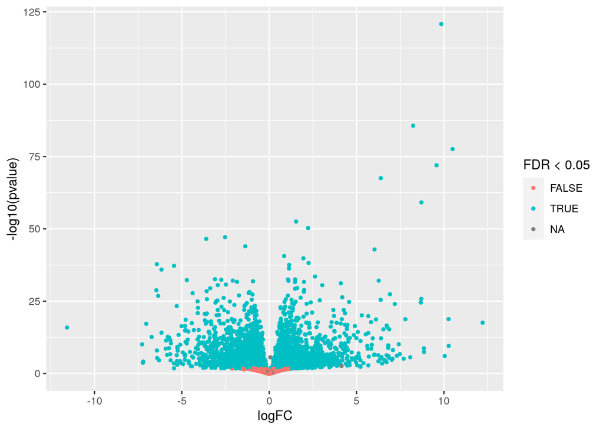

```r
shrinkLvV %>%
    mutate(`-log10(pvalue)` = -log10(pvalue)) %>%
    ggplot(aes(x = logFC, y=`-log10(pvalue)`)) +
      geom_point(aes(colour=FDR < 0.05), size=1)
```